## Homework 5

*Enter your name and EID here*

**This homework is due on Feb. 27, 2018 at 7:00pm. Please submit as a PDF file on Canvas.**

For this homework, you will work with a dataset collected by John Holcomb from the North Carolina State Center for Health and Environmental Statistics. This data set contains 1409 birth records from North Carolina in 2001.

```r
NCbirths <- read.csv("http://wilkelab.org/classes/SDS348/data_sets/NCbirths.csv")
head(NCbirths)
```

```
##   Plural Sex MomAge Weeks Gained Smoke BirthWeightGm Low Premie Marital
## 1      1   1     32    40     38     0       3146.85   0      0       0
## 2      1   2     32    37     34     0       3288.60   0      0       0
## 3      1   1     27    39     12     0       3912.30   0      0       0
## 4      1   1     27    39     15     0       3855.60   0      0       0
## 5      1   1     25    39     32     0       3430.35   0      0       0
## 6      1   1     28    43     32     0       3316.95   0      0       0
```

The column contents are as follows:

- **Plural**: 1=single birth, 2=twins, 3=triplets.
- **Sex**: Sex of the baby 1=male 2=female.
- **MomAge**: Mother’s age (in years).
- **Weeks**: Completed weeks of gestation.
- **Gained**: Weight gained during pregnancy (in pounds).
- **BirthWeightGm**: Birth weight in grams.
- **Low**: Indicator for low birth weight, 1=2500 grams or less, 0=otherwise.
- **Premie**: Indicator for premature birth, 1=36 weeks or sooner, 0=otherwise.
- **Marital**: Marital status: 0=married or 1=not married.

**Problem 1 (3 pts):** We are interested in assessing the relationships between the variables in the dataset `NCbirths` and sex of the baby and premature births. Perform a principal components analysis (PCA) on the dataset `NCbirths`. Remove the columns `Sex`, `Premie`, and `Weeks` prior to performing PCA (these contain information on sex of the baby and the time of gestation). Create a scatterplot of PC1 vs. PC2. First, color each point by sex, and then color each point by the indicator of premature birth. What do you observe? Visually, and without doing any calculations, do the birth terms cluster together in principal-component space? Do the sexes cluster together?

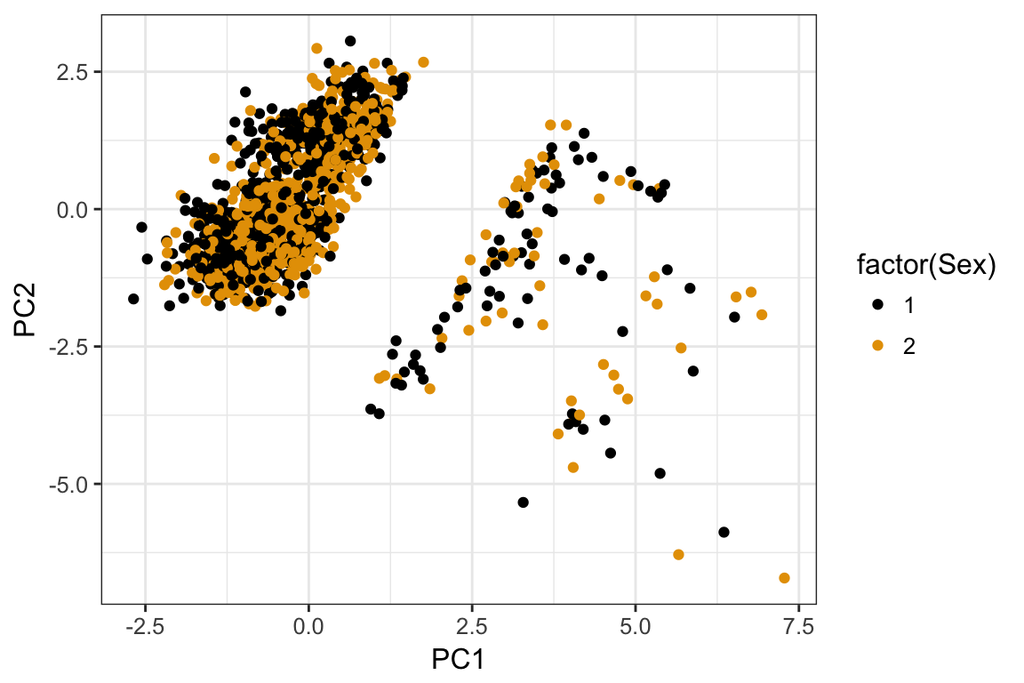

```r
NCbirths %>% select(-Premie, -Sex, -Weeks) %>% scale() %>% prcomp() -> pca

pca_data <- data.frame(pca$x, NCbirths)

ggplot(pca_data, aes(x=PC1, y=PC2, color=factor(Sex))) + geom_point() + scale_color_colorblind()
```

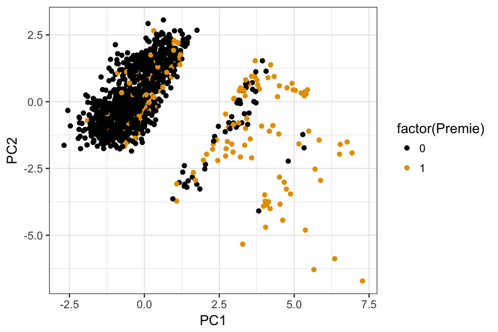

```r
ggplot(pca_data, aes(x=PC1, y=PC2, color=factor(Premie))) + geom_point() + scale_color_colorblind()
```

There seems to be one distinct cluster that mostly contains data for births carried to term, and one cluser that contains data mostly for premature births. The samples do not cluster based on the sex of the baby.

**Problem 2 (4 pts):** Now visualize the rotation matrix of the PCA obtained under Problem 1.

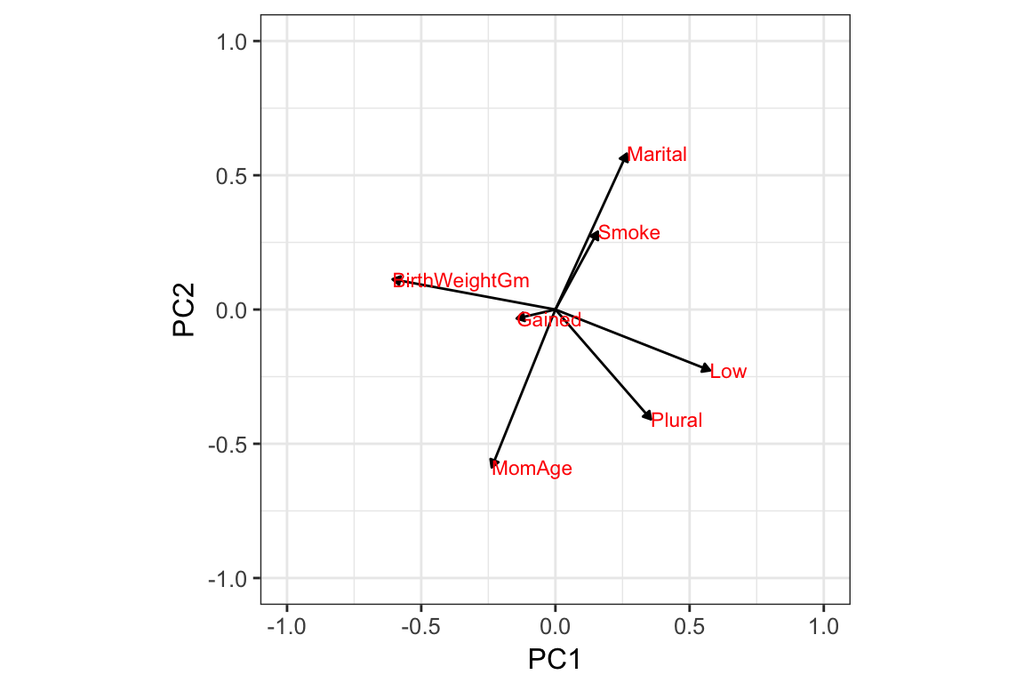

```r
# capture the rotation matrix in a data frame
rotation_data <- data.frame(pca$rotation, variable=row.names(pca$rotation))
# define a pleasing arrow style
arrow_style <- arrow(length = unit(0.05, "inches"),
                     type = "closed")
# now plot, using geom_segment() for arrows and geom_text for labels
ggplot(rotation_data) +
  geom_segment(aes(xend=PC1, yend=PC2), x=0, y=0, arrow=arrow_style) +
  geom_text(aes(x=PC1, y=PC2, label=variable), hjust=0, size=3, color='red') +
  xlim(-1.,1.) +
  ylim(-1.,1.) +
  coord_fixed() # fix aspect ratio to 1:1
```

Given the plots from Problem 1 and the arrow plot you made, how do you interpret PC1 and PC2? What does PC1 tell you about a data point? What does PC2 tell you about a data point?

Most of the variables contribute to PC1 and to PC2. The variable `Gained` that measures the weight gained during pregrnancy contributes very little to PC1 and PC2.

PC1 seems to measure the difference between premature births and births carried to term. PC2 seems to measure mother’s health and age.

**Problem 3 (3 pts):** Create a bar plot that shows the percent variance explained by each principal component. State how much variance is explained by each of the principal components 1 through 4.

```r
percent <- 100*pca$sdev^2/sum(pca$sdev^2)

percent
```

```
## [1] 29.228916 21.603071 15.131260 13.452435  8.641877  7.402678  4.539764
```

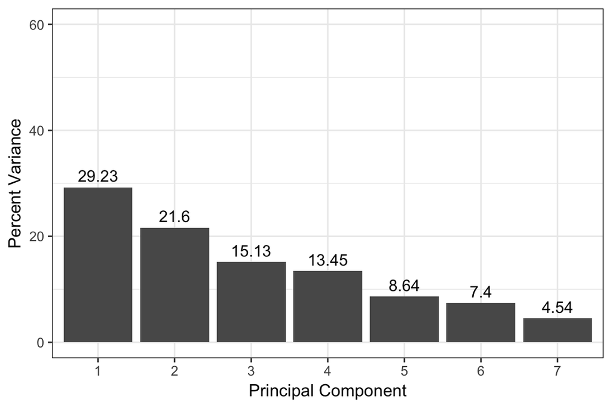

```r
perc_data <- top_n(data.frame(percent=percent, PC=1:length(percent)), 10, percent)
ggplot(perc_data, aes(x=factor(PC), y=percent)) +
  geom_bar(stat="identity") +
  geom_text(aes(label=round(percent, 2)), size=4, vjust=-.5) +
  ylim(0, 60) +
  xlab("Principal Component") +
  ylab("Percent Variance")
```

Principal components 1-4 explain 29.2%, 21.6%, 15.1%, and 13.5% of the variance, respectively.